# Exercise sheet 10

### Task 5

OK, let’s populate `cor_mat`!

#### Task 5.1

Using the code above, write a `for` loop that iterates over each column of `bfi` and correlates if with the 1<sup>st</sup> column of `bfi`, each time saving the test object into `test` and populating the appropriate cell of the `cor_mat` matrix. **Use `i` as the iterator variable.**

The result of the loop should be this partially filled matrix:

```
        [,1] [,2] [,3] [,4] [,5]  [,6]  [,7] [,8] [,9] [,10]
 [1,]  0.000    0    0    0    0 0.219 0.004    0    0     0
 [2,] -0.375   NA   NA   NA   NA    NA    NA   NA   NA    NA
 [3,] -0.301   NA   NA   NA   NA    NA    NA   NA   NA    NA
 [4,] -0.166   NA   NA   NA   NA    NA    NA   NA   NA    NA
 [5,] -0.230   NA   NA   NA   NA    NA    NA   NA   NA    NA
 [6,] -0.026   NA   NA   NA   NA    NA    NA   NA   NA    NA
 [7,]  0.061   NA   NA   NA   NA    NA    NA   NA   NA    NA
 [8,] -0.096   NA   NA   NA   NA    NA    NA   NA   NA    NA
 [9,] -0.100   NA   NA   NA   NA    NA    NA   NA   NA    NA
[10,]  0.126   NA   NA   NA   NA    NA    NA   NA   NA    NA
```

**Hint**

Apart from being the iterator variable, `i` can also be used to subset `bfi` and the rows/columns of `cor_mat`.

**Solution**

```r
# let's start with a fresh cor_mat
cor_mat <- matrix(NA, nrow = 10, ncol = 10)

# i might equally well iterate over:
# 1:10
# 1:ncol(bfi)
for (i in seq_along(bfi)) {
  test <- cor.test(bfi[[i]], bfi[[1]], method = "spearman", exact = F)
  cor_mat[i, 1] <- round(test$estimate, 3)
  cor_mat[1, i] <- round(test$p.value, 3)
}
```

#### Task 5.2

Edit the loop you just created so that it now uses `j` as the iterator variable and correlates `i`<sup>th</sup> and `j`th columns of `bfi`, storing the results into appropriate cells of `cor_mat` again. Starting with an empty matrix, this is what we are after:

```
       [,1]   [,2]   [,3]  [,4]   [,5]   [,6]  [,7]  [,8]   [,9] [,10]
 [1,]    NA     NA     NA    NA     NA     NA    NA    NA     NA 0.000
 [2,]    NA     NA     NA    NA     NA     NA    NA    NA     NA 0.000
 [3,]    NA     NA     NA    NA     NA     NA    NA    NA     NA 0.000
 [4,]    NA     NA     NA    NA     NA     NA    NA    NA     NA 0.083
 [5,]    NA     NA     NA    NA     NA     NA    NA    NA     NA 0.003
 [6,]    NA     NA     NA    NA     NA     NA    NA    NA     NA 0.000
 [7,]    NA     NA     NA    NA     NA     NA    NA    NA     NA 0.000
 [8,]    NA     NA     NA    NA     NA     NA    NA    NA     NA 0.000
 [9,]    NA     NA     NA    NA     NA     NA    NA    NA     NA 0.000
[10,] 0.126 -0.103 -0.075 0.037 -0.063 -0.304 0.355 -0.37 -0.242 0.000
```

**Hint**

`cor_mat[i, j]` should contain the rho, while `cor_mat[j, i]` should contain the *p*=value.

**Solution**

```r
cor_mat <- matrix(NA, nrow = 10, ncol = 10)

# remember, i is still 10 thanks to the loop we ran earlier
for (j in seq_along(bfi)) {
  test <- cor.test(bfi[[i]], bfi[[j]], method = "spearman", exact = F)
  cor_mat[i, j] <- round(test$estimate, 3)
  cor_mat[j, i] <- round(test$p.value, 3)
}
```

#### Task 5.3

Now, combine the two loops using nesting. The outer loop should use `i` and the inner one `j` as iterator variables. This way, for each value of `i`, there will be 10 cycles of the `j` loop. The code inside the inner loop can stay the same while the outer loop does not need any code of its own.

**Hint**

Nesting loops, just like `if` statements is perfectly *kosher*:

```r
for (i in some_vector) {
  for (j in same_or_another_vector) {
    some.code
  }
}
```

**Solution**

```r
cor_mat <- matrix(NA, nrow = 10, ncol = 10)

for (i in seq_along(bfi)) {
  for (j in seq_along(bfi)) {
    test <- cor.test(bfi[[i]], bfi[[j]], method = "spearman", exact = F)
    cor_mat[i, j] <- round(test$estimate, 3)
    cor_mat[j, i] <- round(test$p.value, 3)
  }
}

cor_mat
        [,1]   [,2]   [,3]   [,4]   [,5]   [,6]   [,7]   [,8]   [,9] [,10]
 [1,]  0.000  0.000  0.000  0.000  0.000  0.219  0.004  0.000  0.000 0.000
 [2,] -0.375  0.000  0.000  0.000  0.000  0.000  0.862  0.000  0.000 0.000
 [3,] -0.301  0.510  0.000  0.000  0.000  0.000  0.625  0.000  0.020 0.000
 [4,] -0.166  0.348  0.378  0.000  0.000  0.024  0.043  0.048  0.014 0.083
 [5,] -0.230  0.406  0.530  0.323  0.000  0.000  0.406  0.000  0.361 0.003
 [6,] -0.026  0.127  0.165  0.048  0.164  0.000  0.000  0.000  0.000 0.000
 [7,]  0.061  0.004 -0.010  0.043 -0.018 -0.264  0.000  0.000  0.000 0.000
 [8,] -0.096  0.156  0.231  0.042  0.230  0.412 -0.324  0.000  0.000 0.000
 [9,] -0.100  0.076  0.049 -0.052  0.019  0.240 -0.123  0.227  0.000 0.000
[10,]  0.126 -0.103 -0.075  0.037 -0.063 -0.304  0.355 -0.370 -0.242 0.000
```

As you can see, the diagonal of the matrix contains 0s. This is because when `i` and `j` are equal, the code first populates the corresponding cell of `cor_mat` with the rho and then overwrites it with the *p*-value.

#### Task 5.4

Include a conditional statement inside your loop that tells `R` to only evaluate the code if `i` and `j` are not equal. That way, the diagonal cell will not get populated at all.

**Solution**

```r
cor_mat <- matrix(NA, nrow = 10, ncol = 10)

for (i in seq_along(bfi)) {
  for (j in seq_along(bfi)) {
    if (i != j) {
      test <- cor.test(bfi[[i]], bfi[[j]], method = "spearman", exact = F)
      cor_mat[i, j] <- round(test$estimate, 3)
      cor_mat[j, i] <- round(test$p.value, 3)
    }
  }
}

cor_mat
        [,1]   [,2]   [,3]   [,4]   [,5]   [,6]   [,7]   [,8]   [,9] [,10]
 [1,]     NA  0.000  0.000  0.000  0.000  0.219  0.004  0.000  0.000 0.000
 [2,] -0.375     NA  0.000  0.000  0.000  0.000  0.862  0.000  0.000 0.000
 [3,] -0.301  0.510     NA  0.000  0.000  0.000  0.625  0.000  0.020 0.000
 [4,] -0.166  0.348  0.378     NA  0.000  0.024  0.043  0.048  0.014 0.083
 [5,] -0.230  0.406  0.530  0.323     NA  0.000  0.406  0.000  0.361 0.003
 [6,] -0.026  0.127  0.165  0.048  0.164     NA  0.000  0.000  0.000 0.000
 [7,]  0.061  0.004 -0.010  0.043 -0.018 -0.264     NA  0.000  0.000 0.000
 [8,] -0.096  0.156  0.231  0.042  0.230  0.412 -0.324     NA  0.000 0.000
 [9,] -0.100  0.076  0.049 -0.052  0.019  0.240 -0.123  0.227     NA 0.000
[10,]  0.126 -0.103 -0.075  0.037 -0.063 -0.304  0.355 -0.370 -0.242    NA
```

#### Task 5.5

Finally add a condition that populates the *p*-value cell with a character string `"<.001"`, if the *p*-value, rounded to 3 dp, is zero. For this, you may need an intermediate step, first saving `round(test$p.value, 3)` into some object, *e.g.,* pval, and then populating the given cell of `cor_mat` with either its value or `"<.001"` based on whether or not it’s zero.

**Solution**

```r
cor_mat <- matrix(NA, nrow = 10, ncol = 10)

for (i in seq_along(bfi)) {
  for (j in seq_along(bfi)) {
    if (i != j) {
      test <- cor.test(bfi[[i]], bfi[[j]], method = "spearman", exact = F)
      pval <- round(test$p.value, 3)
      cor_mat[i, j] <- round(test$estimate, 3)
      cor_mat[j, i] <- ifelse(pval, pval, "<.001")
    }
  }
}

cor_mat
      [,1]     [,2]     [,3]     [,4]     [,5]     [,6]     [,7]     [,8]    [,9]     [,10]
 [1,] NA       "<.001"  "<.001"  "<.001"  "<.001"  "0.219"  "0.004"  "<.001" "<.001"  "<.001"
 [2,] "-0.375" NA       "<.001"  "<.001"  "<.001"  "<.001"  "0.862"  "<.001" "<.001"  "<.001"
 [3,] "-0.301" "0.51"   NA       "<.001"  "<.001"  "<.001"  "0.625"  "<.001" "0.02"   "<.001"
 [4,] "-0.166" "0.348"  "0.378"  NA       "<.001"  "0.024"  "0.043"  "0.048" "0.014"  "0.083"
 [5,] "-0.23"  "0.406"  "0.53"   "0.323"  NA       "<.001"  "0.406"  "<.001" "0.361"  "0.003"
 [6,] "-0.026" "0.127"  "0.165"  "0.048"  "0.164"  NA       "<.001"  "<.001" "<.001"  "<.001"
 [7,] "0.061"  "0.004"  "-0.01"  "0.043"  "-0.018" "-0.264" NA       "<.001" "<.001"  "<.001"
 [8,] "-0.096" "0.156"  "0.231"  "0.042"  "0.23"   "0.412"  "-0.324" NA      "<.001"  "<.001"
 [9,] "-0.1"   "0.076"  "0.049"  "-0.052" "0.019"  "0.24"   "-0.123" "0.227" NA       "<.001"
[10,] "0.126"  "-0.103" "-0.075" "0.037"  "-0.063" "-0.304" "0.355"  "-0.37" "-0.242" NA
```

And there’s our correlation table. You will have probably noticed that this is now a character matrix (hence the quotes). This conversion happened because we entered `"<.001"` in some of the cells. Since, as you will recall, matrices can only contain elements of the same class, combining character strings with numeric elements will result in the entire matrix being coerced into character. It looks a little odd printed out like this but, since this is the kind of matrix we might be exporting to a paper and not one we would want to use for any further calculations, it does not matter.

You might have also spotted the fact that the cells of our matrix get populated exactly twice (for instance when `i` = 2 and `j` = 5 and when it’s the other way around). This means that we are running twice as many iterations that we necessarily need. Here is what the process looks like:

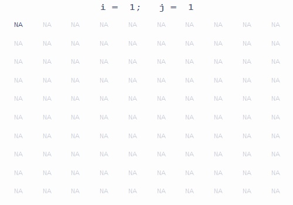

While this is not a huge deal with a small matrix and a fairly simple code inside of the loop, with added complexity, this kind of inefficiency can make a difference.

If you stop to think about it, we don’t really need `i` and `j` to iterate over `1:10`. It is sufficient for `i` to iterate over `1:9` and `j` to be larger than `i` and 10 at most. This approach populates the matrix more efficiently:

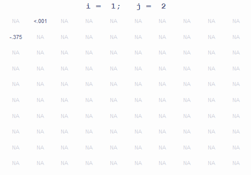

This approach also gets rid of the need to worry about the diagonal elements so it also makes the code simpler, further cutting on processing time. First, let’s time the original solution:

```r
cor_mat <- matrix(NA, nrow = 10, ncol = 10)

iter <- 0 # cycle counter
start <- Sys.time() # stopwatch starts
for (i in seq_along(bfi)) {
  for (j in seq_along(bfi)) {
    if (i != j) {
      test <- cor.test(bfi[[i]], bfi[[j]], method = "spearman", exact = F)
      pval <- round(test$p.value, 3)
      cor_mat[i, j] <- round(test$estimate, 3)
      cor_mat[j, i] <- ifelse(pval, pval, "<.001")
    }
    iter <- iter + 1 # add cycle
  }
}
end <- Sys.time() # stopwatch ends
```

Number of iterations run: 100

Time taken to compute: 0.075s

And now the streamlined solution (click to copy code):

```r
cor_mat <- matrix(NA, nrow = 10, ncol = 10)

iter <- 0
start <- Sys.time()
for (i in 1:(ncol(bfi) - 1)) {
  for (j in (i + 1):ncol(bfi)) {
    test <- cor.test(bfi[[i]], bfi[[j]], method = "spearman", exact = F)
    pval <- round(test$p.value, 3)
    cor_mat[j, i] <- round(test$estimate, 3) # had to swap i and j around
    cor_mat[i, j] <- ifelse(pval, pval, "<.001")
    iter <- iter + 1
  }
}
end <- Sys.time()
cor_mat
```

```
      [,1]     [,2]     [,3]     [,4]     [,5]     [,6]     [,7]     [,8]    [,9]     [,10]
 [1,] NA       "<.001"  "<.001"  "<.001"  "<.001"  "0.219"  "0.004"  "<.001" "<.001"  "<.001"
 [2,] "-0.375" NA       "<.001"  "<.001"  "<.001"  "<.001"  "0.862"  "<.001" "<.001"  "<.001"
 [3,] "-0.301" "0.51"   NA       "<.001"  "<.001"  "<.001"  "0.625"  "<.001" "0.02"   "<.001"
 [4,] "-0.166" "0.348"  "0.378"  NA       "<.001"  "0.024"  "0.043"  "0.048" "0.014"  "0.083"
 [5,] "-0.23"  "0.406"  "0.53"   "0.323"  NA       "<.001"  "0.406"  "<.001" "0.361"  "0.003"
 [6,] "-0.026" "0.127"  "0.165"  "0.048"  "0.164"  NA       "<.001"  "<.001" "<.001"  "<.001"
 [7,] "0.061"  "0.004"  "-0.01"  "0.043"  "-0.018" "-0.264" NA       "<.001" "<.001"  "<.001"
 [8,] "-0.096" "0.156"  "0.231"  "0.042"  "0.23"   "0.412"  "-0.324" NA      "<.001"  "<.001"
 [9,] "-0.1"   "0.076"  "0.049"  "-0.052" "0.019"  "0.24"   "-0.123" "0.227" NA       "<.001"
[10,] "0.126"  "-0.103" "-0.075" "0.037"  "-0.063" "-0.304" "0.355"  "-0.37" "-0.242" NA
```

Number of iterations run: 45

Time taken to compute: 0.045s

Efficiency is just nice! Speaking of which, as mentioned above, this task doesn’t really require a `for` loop. The `Hmisc::rcorr()` function can be used to get a matrix of correlations and a matrix of *p*-values. In fact, that is how the table at the beginning of this sheet was made:

```r
temp <- Hmisc::rcorr(as.matrix(bfi), type = "spearman") # output is a list of several things
cor_mat <- round(temp$r, 3) # $r is the correlation matrix
pvals <- round(temp$P, 3) # $P is the matrix of p-values

# replace the upper triangle of cor_mat with the upper triangle of pvals
cor_mat[upper.tri(cor_mat)] <- pvals[upper.tri(pvals)]
## the rest is just cosmetics
# force 3 dp so that 0.1 gets formatted as 0.100
cor_mat <- format(cor_mat, nsmall = 3)
# replace diagonal with empty strings
diag(cor_mat) <- ""
# replace 0 with "<.001
cor_mat[as.numeric(cor_mat) == 0] <- "<.001"
# format - to show as actual minus signs in output file
# at the same time delete leading zero from negative numbers, e.g. -0.020 -> $-$.020
cor_mat <- gsub("^-0", "$-$", cor_mat)
# get rid of leading zero in all other cells
cor_mat <- gsub("^\\s*0", " ", cor_mat)
# make row names appear in bold in output file
row.names(cor_mat) <- paste0("**", row.names(cor_mat), "**")
# format as table for output file
cor_mat %>% knitr::kable(align="r") %>% kableExtra::kable_styling()
```

|  | A1 | A2 | A3 | A4 | A5 | O1 | O2 | O3 | O4 | O5 |
| --- | --- | --- | --- | --- | --- | --- | --- | --- | --- | --- |
| **A1** |  | <.001 | <.001 | <.001 | <.001 | .219 | .004 | <.001 | <.001 | <.001 |
| **A2** | $-$.375 |  | <.001 | <.001 | <.001 | <.001 | .862 | <.001 | <.001 | <.001 |
| **A3** | $-$.301 | .510 |  | <.001 | <.001 | <.001 | .625 | <.001 | .020 | <.001 |
| **A4** | $-$.166 | .348 | .378 |  | <.001 | .024 | .043 | .048 | .014 | .083 |
| **A5** | $-$.230 | .406 | .530 | .323 |  | <.001 | .406 | <.001 | .361 | .003 |
| **O1** | $-$.026 | .127 | .165 | .048 | .164 |  | <.001 | <.001 | <.001 | <.001 |
| **O2** | .061 | .004 | $-$.010 | .043 | $-$.018 | $-$.264 |  | <.001 | <.001 | <.001 |
| **O3** | $-$.096 | .156 | .231 | .042 | .230 | .412 | $-$.324 |  | <.001 | <.001 |
| **O4** | $-$.100 | .076 | .049 | $-$.052 | .019 | .240 | $-$.123 | .227 |  | <.001 |
| **O5** | .126 | $-$.103 | $-$.075 | .037 | $-$.063 | $-$.304 | .355 | $-$.370 | $-$.242 |  |

However, the exercise was still valuable.

## Reflect

In this session you have:

- practised writing `for` loops
- deepened your understanding how iteration in `R` works
- realised that iterator variables can be used to subset data structures
- exercised your algorithmic thinking by breaking down a relatively complex problem into a series of repeatable steps
- hopefully learned to appreciate efficiency in coding.

Well done!